# fordgobike_slide_deck slides

## New york Fordgobike 2019 data analysis

### Investigation Overview

###### In this investigation, I wanted to look at the most user characteristics are the best in predicting the trip duration, and how this characteristics are related with rental time period, also im intersted to study what feature among added weather features are the best in predicting the daily trip count and the total daily rent time.

### Dataset Overview

##### The dataset is a recodrs of 369969 trips the attributes included the trip informations as date, strat/end trip time, start/end trip station, as well as additional information about users like gender, type and birthday and added weather informations like temperature, wind speed, humidity, precipitations. 34978 data points were removed from the analysis due to inconsistencies or missing information.

## Distribution of trip count

Trip duration in this dataset take a range from 1 to 240 min at the highest. Plotted on a logarithmic scale, the distribution of trip duration takes on a unimodal shape.

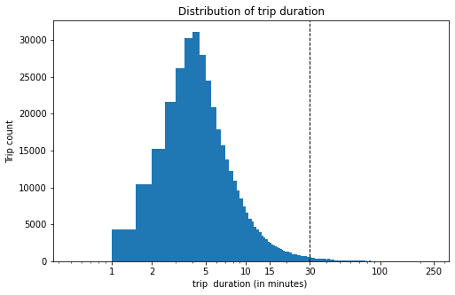

### Poucentage of users by periods age, gender and type

- Young and middle-aged adults contributed the majority of service users in 2019 with 47.35% and 45.23% respectively, on other hand old and adolescent are rarely observed in this dataset with 7.37% and 0.04% respectively.
- Males are the most present gender in this dataset with a percentage of 70.81% followed by females with a percentage of 22.77% however there remains another percentage of 6.42% identified as 'unknown'. -Subscriber dominate with 89,48% while pourcentage of custumers is 10.52%.

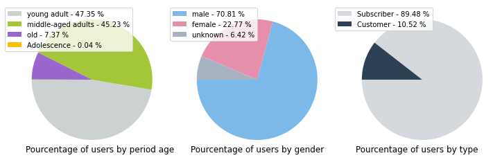

### Time-dependent use

- The use according to the month of year shows peaks in August and September, unlike February which recorded the lowest number of trips
- Tuesday, Wednesday and Friday recorded the highest number of trips while Sunday, which represents the day of the week that recorded the lowest number of trips
- According to hourly usage, 8 a.m, 5 p.m. and 6 p.m. recorded peaks of use

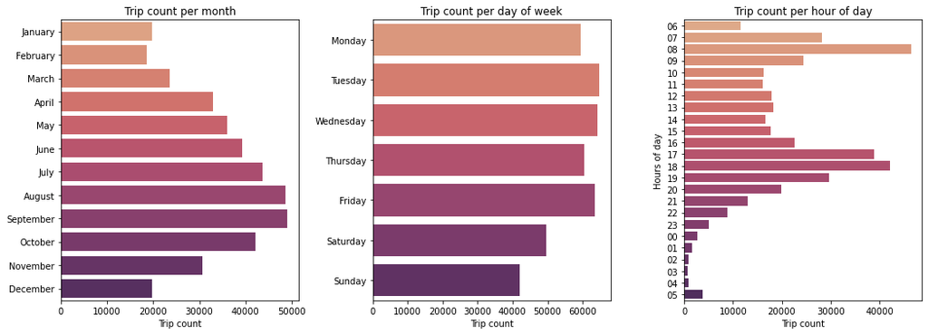

### Daily trip count and weather relationship

There is a strong relationship between the temperature and the daily trip count, this relationship will predict the number of trips according to the daily temperature, another relationship also exists with humidity but to a lesser degree.

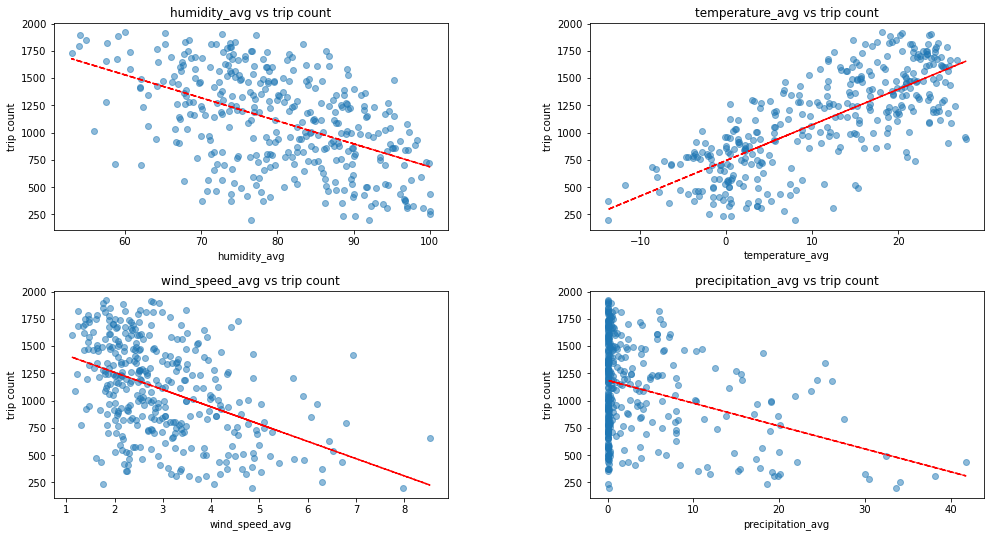

### Total daily rent time, temperature and age relationship by gender

- Total daily rent time is strongly related to temperature.
- the relationship between temperature and total daily rent time is positive, the more the temperature increases the more the total daily rent time increases in parallel.
- The ratio of females is significantly related to temperature the more the temperature increases the more the ratio of females increases in parallel.
- For both male and female the more the temperature the more the average age of the users decreases.

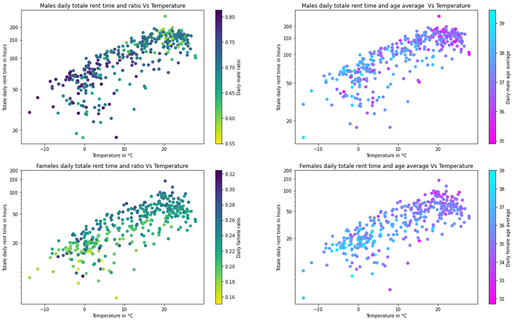

### Total daily rent time, temperature and age relationship by user type

- for subscriber and custumers more the temperature increases more the total daily rent time increases
- More the temperature increases more the custumers ratio increases and the subscriber ratio decrease
- More the temperature increases more the subscriber age average decreases on the other hand more the temperature increases, more the custumers average age increases.

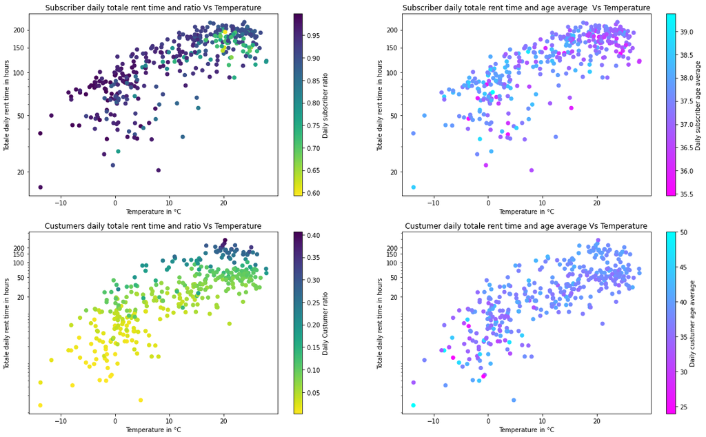

### Total daily rent time and temperature relationship by day type

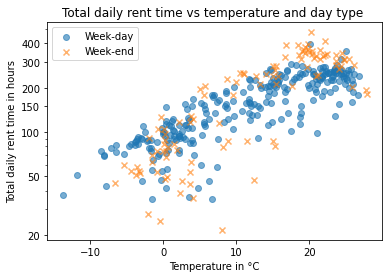